# Analyzing textual data

In this lab we will work through an example of text mining. First we will download the complete text of Romeo and Juliet:

```r
randj <- readLines("http://www.gutenberg.org/cache/epub/1112/pg1112.txt")
```

Let’s remove the header information from the file and inspect beginning of the play.

```r
randj <- randj[-(1:65)]
head(randj, 20)
```

```
##  [1] "THE TRAGEDY OF ROMEO AND JULIET"
##  [2] ""
##  [3] "by William Shakespeare"
##  [4] ""
##  [5] ""
##  [6] ""
##  [7] "Dramatis Personae"
##  [8] ""
##  [9] "  Chorus."
## [10] ""
## [11] ""
## [12] "  Escalus, Prince of Verona."
## [13] ""
## [14] "  Paris, a young Count, kinsman to the Prince."
## [15] ""
## [16] "  Montague, heads of two houses at variance with each other."
## [17] ""
## [18] "  Capulet, heads of two houses at variance with each other."
## [19] ""
## [20] "  An old Man, of the Capulet family."
```

**Exercise**. How many lines are there in the play? Don’t count empty lines.

# Zipf’s law

In the first part of this lab we will create a histogram of the word frequency distribution i.e. how many words appear only once, how many words appear twice etc.

**Step 1** Notice that play is provided as a list of lines. Split each line into a vector so that each entry in the vector contains only one word (Hint recall the `str.split` function.)

**Step 2** Concatenate all of the vectors into a single long vector.

**Step 3** Use table to find out how many times each word appears in the vector.

**Step 4** Use table a second time to find out how many words appear only once, how many appear twice etc.

**Step 5** Plot your results as a histogram. You should get something that looks like this>

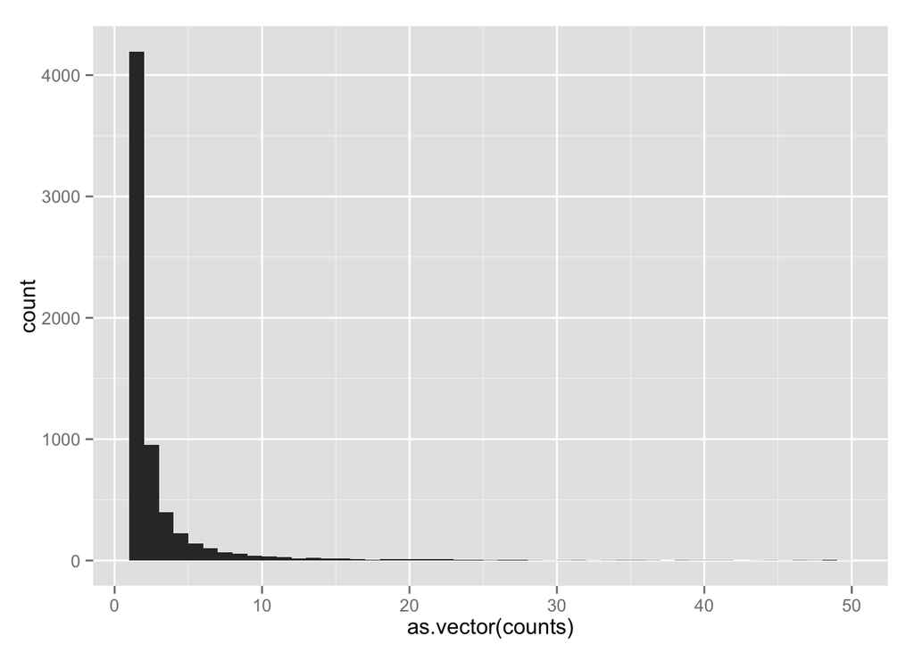

# Making a word cloud.

For this part we will be using the package `wordcloud`. Let’s load it now.

```r
library(wordcloud)
```

The function we want is called `wordcloud` too. Have a look at the helpfile.

```r
?wordcloud
```

**Exercise** Use the `wordcloud` function to make a wordcloud for 100 most common words in Romeo and Juliet. Make sure to the empty string “” is not in your list of words! It should look something like this:

[figure not shown]

Notice that there are are many words that are not all that interesting. Fortunately some people have already collected a list of these very common words. They call them stop words:

```r
#install.packages("tm")
library(tm)
stopwords(kind = "en")
```

```
##   [1] "i"          "me"         "my"         "myself"     "we"
##   [6] "our"        "ours"       "ourselves"  "you"        "your"
##  [11] "yours"      "yourself"   "yourselves" "he"         "him"
##  [16] "his"        "himself"    "she"        "her"        "hers"
##  [21] "herself"    "it"         "its"        "itself"     "they"
##  [26] "them"       "their"      "theirs"     "themselves" "what"
##  [31] "which"      "who"        "whom"       "this"       "that"
##  [36] "these"      "those"      "am"         "is"         "are"
##  [41] "was"        "were"       "be"         "been"       "being"
##  [46] "have"       "has"        "had"        "having"     "do"
##  [51] "does"       "did"        "doing"      "would"      "should"
##  [56] "could"      "ought"      "i'm"        "you're"     "he's"
##  [61] "she's"      "it's"       "we're"      "they're"    "i've"
##  [66] "you've"     "we've"      "they've"    "i'd"        "you'd"
##  [71] "he'd"       "she'd"      "we'd"       "they'd"     "i'll"
```

[output cut: 20 more lines]

**Exercise** Remake your word cloud excluding the these very common words.